# Assignment 2 STA4102

Emily

## Question 1

```r
#Loading in data
traindf=read.csv("/Users/admin/Documents/Csvv/train1.csv",header = T,stringsAsFactors = T)
testdf=read.csv("/Users/admin/Documents/Csvv/test1.csv",header = T,stringsAsFactors = T)
```

```r
#loading in libraries
library(leaps)
library(xgboost)
library(rpart)
```

```r
library(rpart.plot)
library(randomForest)
library(dplyr)
library(Metrics)
```

```r
#merging the two subsets into one whole temporary Dataframe
tempdf=bind_rows(traindf,testdf)
```

```r
#Seeign dimensions
dim(traindf)
```

```
## [1] 1460   81
```

```r
dim(testdf)
```

```
## [1] 1459   81
```

```r
dim(tempdf)
```

```
## [1] 2919   81
```

```r
#creating a temporary variable to find Na values by columns
ColNas=colSums(is.na(tempdf))
```

```r
#Creating Dataframe to find which # column the NA values are in to remove
Nadf=cbind(ColNas,seq(1,length(colnames(tempdf)),by=1))
Nadf=as.data.frame(Nadf)
```

```r
#finding which columns have na values
Nadf[which(Nadf$ColNas>0),]
```

```
##              ColNas V2
## MSZoning          4  3
## LotFrontage     465  4
## Alley          2721  7
## Utilities         2 10
## Exterior1st       1 24
## Exterior2nd       1 25
## MasVnrType       24 26
## MasVnrArea       23 27
## BsmtQual         81 31
## BsmtCond         82 32
## BsmtExposure     82 33
## BsmtFinType1     79 34
## BsmtFinSF1        1 35
## BsmtFinType2     80 36
## BsmtFinSF2        1 37
## BsmtUnfSF         1 38
## TotalBsmtSF       1 39
## Electrical        1 43
## BsmtFullBath      2 48
## BsmtHalfBath      2 49
## KitchenQual       1 54
## Functional        2 56
## FireplaceQu    1420 58
## GarageType      157 59
## GarageYrBlt     159 60
## GarageFinish    159 61
## GarageCars        1 62
## GarageArea        1 63
## GarageQual      159 64
## GarageCond      159 65
## PoolQC         2909 73
## Fence          2348 74
## MiscFeature    2814 75
## SaleType          1 79
```

```r
#removing Na values from whole dataset
NoNadf=tempdf[,-c(7,58,59,60,61,64,65,73,74,75)]
NoNa.df=na.omit(NoNadf)
```

```r
str(NoNa.df)
```

```
## 'data.frame':    2355 obs. of  71 variables:
##  $ Id           : int  1 2 3 4 5 6 7 8 9 10 ...
##  $ MSSubClass   : int  60 20 60 70 60 50 20 60 50 190 ...
##  $ MSZoning     : Factor w/ 5 levels "C (all)","FV",..: 4 4 4 4 4 4 4 4 5 4 ...
##  $ LotFrontage  : int  65 80 68 60 84 85 75 0 51 50 ...
##  $ LotArea      : int  8450 9600 11250 9550 14260 14115 10084 10382 6120 7420 ...
##  $ Street       : Factor w/ 2 levels "Grvl","Pave": 2 2 2 2 2 2 2 2 2 2 ...
##  $ LotShape     : Factor w/ 4 levels "IR1","IR2","IR3",..: 4 4 1 1 1 1 4 1 4 4 ...
##  $ LandContour  : Factor w/ 4 levels "Bnk","HLS","Low",..: 4 4 4 4 4 4 4 4 4 4 ...
##  $ Utilities    : Factor w/ 2 levels "AllPub","NoSeWa": 1 1 1 1 1 1 1 1 1 1 ...
##  $ LotConfig    : Factor w/ 5 levels "Corner","CulDSac",..: 5 3 5 1 3 5 5 1 5 1 ...
##  $ LandSlope    : Factor w/ 3 levels "Gtl","Mod","Sev": 1 1 1 1 1 1 1 1 1 1 ...
##  $ Neighborhood : Factor w/ 25 levels "Blmngtn","Blueste",..: 6 25 6 7 14 12 21 17 18 4 ...
##  $ Condition1   : Factor w/ 9 levels "Artery","Feedr",..: 3 2 3 3 3 3 3 5 1 1 ...
##  $ Condition2   : Factor w/ 8 levels "Artery","Feedr",..: 3 3 3 3 3 3 3 3 3 1 ...
```

[output cut: 59 more lines]

```r
#getting training and testing dataset again
Training=NoNa.df[which(NoNa.df$Id<length(traindf$Id)),]
Testing=NoNa.df[-which(NoNa.df$Id<length(traindf$Id)),]
```

```r
dim(Training)
```

```
## [1] 1181   71
```

```r
dim(Testing)
```

```
## [1] 1174   71
```

```r
#creating dummy variables in model to apply subset selection
train_mat=model.matrix(SalePrice~., data=Training)
training_x=as.data.frame(train_mat)

#Getting response training variable
training_y=Training[,length(colnames(Training))]
```

```r
test_mat=model.matrix(SalePrice~., data=Testing)
testing_x=as.data.frame(test_mat)

#Getting response testing variable
testing_y=Testing[,length(colnames(Testing))]
```

```r
dim(training_x)
```

```
## [1] 1181  218
```

```r
dim(testing_x)
```

```
## [1] 1174  218
```

**Selecting variables for the models to use**

```r
#using forward selection
frdreg = regsubsets(SalePrice~., data=Training,nvmax = 10,method="forward")
```

```
## Reordering variables and trying again:
```

```r
reg.summary = summary(frdreg)
coef(frdreg, 10)
```

```
##         (Intercept)          MSSubClass NeighborhoodNPkVill  NeighborhoodNWAmes
##       -3.478496e+06       -6.796609e+01       -1.748564e+04        1.524660e+03
##   NeighborhoodSWISU        YearRemodAdd        RoofStyleHip     BsmtFinType1Unf
##       -2.089940e+03        1.834911e+03        4.364660e+04       -4.257704e+04
##           BsmtUnfSF      FunctionalMin1         SaleTypeCon
##        4.445123e+01       -2.504371e+04        6.406446e+04
```

The 10 variables we are chosing to build our models are

1. MSSubClass
2. NeighborhoodNPkVill
3. NeighborhoodNWAmes
4. NeighborhoodSWISU
5. YearRemodAdd
6. RoofStyleHip
7. BsmtFinType1Unf
8. BsmtUnfSF
9. FunctionalMin1
10. SaleTypeCon

**Part A**:  
Building a multiple linear regression model

```r
lin.reg=lm(Training$SalePrice~ MSSubClass + NeighborhoodNPkVill + NeighborhoodNWAmes + NeighborhoodSWISU + YearRemodAdd + RoofStyleHip + BsmtFinType1Unf + BsmtUnfSF + FunctionalMin1 + SaleTypeCon,
           data=training_x)
```

```r
lin.pred=predict(lin.reg,newdata = testing_x)
MSE = (mean(testing_y - lin.pred)^2)
RMSE = sqrt(MSE)
RMSE
```

```
## [1] 86.86281
```

The RMSE is 86.86

**Part B**:  
Bulding a decision tree model with the 10 variables

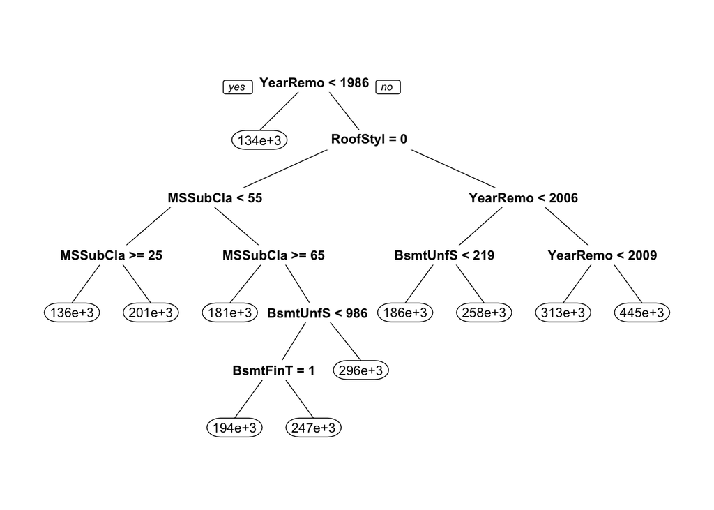

```r
SalesM1=rpart(Training$SalePrice~ MSSubClass + NeighborhoodNPkVill + NeighborhoodNWAmes + NeighborhoodSWISU + YearRemodAdd + RoofStyleHip + BsmtFinType1Unf + BsmtUnfSF + FunctionalMin1 + SaleTypeCon,
           data=training_x)
prp(SalesM1)
```

```r
Tree.Pred = predict(SalesM1, newdata=testing_x)
MSE1 = mean( (testing_y - Tree.Pred)^2)
RMSE1 = sqrt(MSE1)
RMSE1
```

```
## [1] 55467.37
```

```r
RMSE.tp=rmse(actual= testing_y, predicted = Tree.Pred)
RMSE.tp
```

```
## [1] 55467.37
```

The RMSE is 55467.37 for this model.

```r
Regr = randomForest( x = training_x ,y=training_y ,ntree=1000)
```

```r
RandomForest_Pred = predict(Regr,newdata=testing_x)
```

```r
MSE2 = mean( ( testing_y - RandomForest_Pred )^2 )
RMSE2 = sqrt(MSE2)
RMSE2
```

```
## [1] 70308.42
```

```r
RMSE.tp1=rmse(actual= testing_y, predicted = RandomForest_Pred)
RMSE.tp1
```

```
## [1] 70308.42
```

**Part D**:  
XGBoost

```r
param=list( eta=0.4, subsample=0.5, max_depth=4)
xgb.fit = xgboost(as.matrix(training_x), label = training_y, params=param ,nrounds=100,  verbose=0 )
```

```r
pre.xg=predict(xgb.fit , newdata= as.matrix(testing_x))
MSE3 = mean( ( testing_y - pre.xg )^2 )
RMSE3 = sqrt(MSE3)
RMSE3
```

```
## [1] 74462.39
```

```r
RMSE.tp2=rmse(actual= testing_y, predicted = pre.xg)
RMSE.tp2
```

```
## [1] 74462.39
```

**Part E**:  
Eta: the learning rate is a parameter that you can change which will affect your RMSE and the Max depths.

## Question 2

```r
#Loading in Data
PokemonData=read.csv("/Users/admin/Documents/Csvv/pokemon.csv",stringsAsFactors = T, header=T, na.strings = "n/a", " ",sep=",")
```

```r
#loading in libraries
library(caret)
```

```r
library(rpart)
library(rpart.plot)
library(randomForest)
library(tree)
library(xgboost)
```

```r
str(PokemonData)
```

```
## 'data.frame':    721 obs. of  23 variables:
##  $ Number          : int  1 2 3 4 5 6 7 8 9 10 ...
##  $ Name            : Factor w/ 721 levels "Abomasnow","Abra",..: 68 295 670 87 88 86 595 688 54 82 ...
##  $ Type_1          : Factor w/ 18 levels "Bug","Dark","Dragon",..: 10 10 10 7 7 7 18 18 18 1 ...
##  $ Type_2          : Factor w/ 19 levels "","Bug","Dark",..: 15 15 15 1 1 9 1 1 1 1 ...
##  $ Total           : int  318 405 525 309 405 534 314 405 530 195 ...
##  $ HP              : int  45 60 80 39 58 78 44 59 79 45 ...
##  $ Attack          : int  49 62 82 52 64 84 48 63 83 30 ...
##  $ Defense         : int  49 63 83 43 58 78 65 80 100 35 ...
##  $ Sp_Atk          : int  65 80 100 60 80 109 50 65 85 20 ...
##  $ Sp_Def          : int  65 80 100 50 65 85 64 80 105 20 ...
##  $ Speed           : int  45 60 80 65 80 100 43 58 78 45 ...
##  $ Generation      : int  1 1 1 1 1 1 1 1 1 1 ...
##  $ isLegendary     : Factor w/ 2 levels "False","True": 1 1 1 1 1 1 1 1 1 1 ...
##  $ Color           : Factor w/ 10 levels "Black","Blue",..: 4 4 4 8 8 8 2 2 2 4 ...
##  $ hasGender       : Factor w/ 2 levels "False","True": 2 2 2 2 2 2 2 2 2 2 ...
##  $ Pr_Male         : num  0.875 0.875 0.875 0.875 0.875 0.875 0.875 0.875 0.875 0.5 ...
##  $ Egg_Group_1     : Factor w/ 15 levels "Amorphous","Bug",..: 11 11 11 11 11 11 11 11 11 2 ...
##  $ Egg_Group_2     : Factor w/ 14 levels "","Amorphous",..: 8 8 8 4 4 4 12 12 12 1 ...
##  $ hasMegaEvolution: Factor w/ 2 levels "False","True": 1 1 2 1 1 2 1 1 2 1 ...
##  $ Height_m        : num  0.71 0.99 2.01 0.61 1.09 1.7 0.51 0.99 1.6 0.3 ...
##  $ Weight_kg       : num  6.9 13 100 8.5 19 90.5 9 22.5 85.5 2.9 ...
##  $ Catch_Rate      : int  45 45 45 45 45 45 45 45 45 255 ...
##  $ Body_Style      : Factor w/ 14 levels "bipedal_tailed",..: 10 10 10 1 1 1 1 1 1 8 ...
```

```r
#Checking which column has Nas
cbind(colSums(is.na(PokemonData)),seq(1,length(colnames(PokemonData)),by=1))
```

```
##                  [,1] [,2]
## Number              0    1
## Name                0    2
## Type_1              0    3
## Type_2              0    4
## Total               0    5
## HP                  0    6
## Attack              0    7
## Defense             0    8
## Sp_Atk              0    9
## Sp_Def              0   10
## Speed               0   11
## Generation          0   12
## isLegendary         0   13
## Color               0   14
## hasGender           0   15
## Pr_Male            77   16
## Egg_Group_1         0   17
## Egg_Group_2         0   18
## hasMegaEvolution    0   19
## Height_m            0   20
## Weight_kg           0   21
## Catch_Rate          0   22
## Body_Style          0   23
```

```r
PokemonData[,16]
```

```
##   [1] 0.875 0.875 0.875 0.875 0.875 0.875 0.875 0.875 0.875 0.500 0.500 0.500
##  [13] 0.500 0.500 0.500 0.500 0.500 0.500 0.500 0.500 0.500 0.500 0.500 0.500
##  [25] 0.500 0.500 0.500 0.500 0.000 0.000 0.000 1.000 1.000 1.000 0.250 0.250
##  [37] 0.250 0.250 0.250 0.250 0.500 0.500 0.500 0.500 0.500 0.500 0.500 0.500
##  [49] 0.500 0.500 0.500 0.500 0.500 0.500 0.500 0.500 0.500 0.750 0.750 0.500
##  [61] 0.500 0.500 0.750 0.750 0.750 0.750 0.750 0.750 0.500 0.500 0.500 0.500
##  [73] 0.500 0.500 0.500 0.500 0.500 0.500 0.500 0.500    NA    NA 0.500 0.500
##  [85] 0.500 0.500 0.500 0.500 0.500 0.500 0.500 0.500 0.500 0.500 0.500 0.500
##  [97] 0.500 0.500 0.500    NA    NA 0.500 0.500 0.500 0.500 1.000 1.000 0.500
## [109] 0.500 0.500 0.500 0.500 0.000 0.500 0.000 0.500 0.500 0.500 0.500    NA
## [121]    NA 0.500 0.500 0.000 0.750 0.750 0.500 1.000 0.500 0.500 0.500    NA
## [133] 0.875 0.875 0.875 0.875    NA 0.875 0.875 0.875 0.875 0.875 0.875    NA
## [145]    NA    NA 0.500 0.500 0.500    NA    NA 0.875 0.875 0.875 0.875 0.875
## [157] 0.875 0.875 0.875 0.875 0.500 0.500 0.500 0.500 0.500 0.500 0.500 0.500
## [169] 0.500 0.500 0.500 0.500 0.250 0.250 0.875 0.875 0.500 0.500 0.500 0.500
```

[output cut: 46 more lines]

```r
#finding the frequency of numbers in this column
tb=table(PokemonData[,16])
sum(tb)
```

```
## [1] 644
```

```r
tb
```

```
##
##     0 0.125  0.25   0.5  0.75 0.875     1
##    23     2    22   458    19   101    19
```

```r
#How many NA values we have
len=sum(is.na(PokemonData$Pr_Male))
len
```

```
## [1] 77
```

```r
#Getting data to impute
set.seed(123)
sam=c(0,0.125,0.25,0.5,0.75,0.875,1)
p=c(23/644,2/644,22/644,458/644,19/644,101/644,19/644)
x=sample(sam,len,prob=p,replace = T)
x
```

```
##  [1] 0.500 0.875 0.500 0.000 1.000 0.500 0.500 0.000 0.500 0.500 1.000 0.500
## [13] 0.500 0.500 0.500 0.000 0.500 0.500 0.500 1.000 0.000 0.500 0.500 0.750
## [25] 0.500 0.500 0.500 0.500 0.500 0.500 1.000 0.000 0.500 0.875 0.500 0.500
## [37] 0.875 0.500 0.500 0.500 0.500 0.500 0.500 0.500 0.500 0.500 0.500 0.500
## [49] 0.500 0.875 0.500 0.500 0.875 0.500 0.500 0.500 0.500 0.875 0.000 0.500
## [61] 0.500 0.500 0.500 0.500 0.875 0.500 0.875 0.875 0.875 0.500 0.875 0.500
## [73] 0.500 0.500 0.500 0.500 0.500
```

```r
colsNa=which(is.na(PokemonData$Pr_Male))
colsNa
```

```
##  [1]  81  82 100 101 120 121 132 137 144 145 146 150 151 201 233 243 244 245 249
## [20] 250 251 292 337 338 343 344 374 375 376 377 378 379 382 383 384 385 386 436
## [39] 437 462 474 479 480 481 482 483 484 486 487 489 490 491 492 493 494 599 600
## [58] 601 615 622 623 638 639 640 643 644 646 647 648 649 703 716 717 718 719 720
## [77] 721
```

```r
PokemonData$Pr_Male[colsNa]
```

```
##  [1] NA NA NA NA NA NA NA NA NA NA NA NA NA NA NA NA NA NA NA NA NA NA NA NA NA
## [26] NA NA NA NA NA NA NA NA NA NA NA NA NA NA NA NA NA NA NA NA NA NA NA NA NA
## [51] NA NA NA NA NA NA NA NA NA NA NA NA NA NA NA NA NA NA NA NA NA NA NA NA NA
## [76] NA NA
```

```r
#imputting data
PokemonData$Pr_Male[colsNa]=x
sum(is.na(PokemonData$Pr_Male))
```

```
## [1] 0
```

```r
PokemonData=PokemonData[,-c(1)]
```

**Part A**

```r
#Creating a data partition, making test and train set
set.seed(12)
trainIdx=createDataPartition(PokemonData$Type_1, p=0.7, list=FALSE, times=1)
trainingDf=PokemonData[ trainIdx ,-c(1) ]
testingDf=PokemonData[-trainIdx ,-c(1)]
```

**Decision Tree**

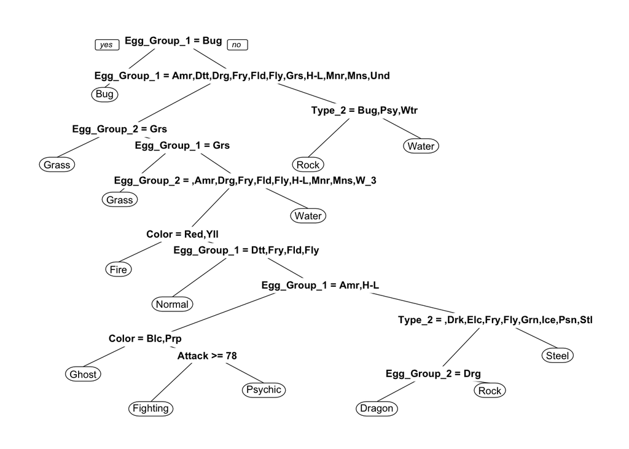

```r
Poke1=rpart(Type_1~. ,data=trainingDf)
prp(Poke1)
```

```r
#Prediction model
Tree.pred=predict(Poke1,newdata=testingDf,type = "class")
```

```r
#accuracy
mean(Tree.pred == testingDf$Type_1)
```

```
## [1] 0.5169082
```

```r
#Confusion matrix
confusionMatrix(table(Tree.pred,testingDf$Type_1))
```

```
## Confusion Matrix and Statistics
##
##
## Tree.pred  Bug Dark Dragon Electric Fairy Fighting Fire Flying Ghost Grass
##   Bug       16    0      0        0     0        0    0      0     0     0
##   Dark       0    0      0        0     0        0    0      0     0     0
##   Dragon     0    0      0        0     0        0    0      0     0     0
##   Electric   0    0      0        0     0        0    0      0     0     0
##   Fairy      0    0      0        0     0        0    0      0     0     0
##   Fighting   0    0      0        0     0        5    0      0     0     0
##   Fire       0    1      0        4     0        0    9      0     0     0
##   Flying     0    0      0        0     0        0    0      0     0     0
##   Ghost      0    0      0        0     0        0    0      0     4     0
##   Grass      0    0      0        0     0        0    0      0     0    17
##   Ground     0    0      0        0     0        0    0      0     0     0
##   Ice        0    0      0        0     0        0    0      0     0     0
##   Normal     0    5      0        4     5        1    4      0     0     1
##   Poison     0    0      0        0     0        0    0      0     0     0
##   Psychic    0    0      0        1     0        0    0      0     1     0
##   Rock       1    0      5        1     0        1    1      0     0     1
##   Steel      0    2      1        0     0        0    0      0     1     0
##   Water      1    0      1        0     0        0    0      0     0     0
##
## Tree.pred  Ground Ice Normal Poison Psychic Rock Steel Water
##   Bug           2   0      0      1       0    0     0     0
##   Dark          0   0      0      0       0    0     0     0
##   Dragon        0   0      0      0       0    0     0     0
##   Electric      0   0      0      0       0    0     0     0
##   Fairy         0   0      0      0       0    0     0     0
##   Fighting      0   0      0      1       0    0     0     0
##   Fire          1   0      2      0       5    2     1     1
##   Flying        0   0      0      0       0    0     0     0
##   Ghost         0   0      0      0       0    0     0     0
##   Grass         0   0      0      0       0    0     0     0
##   Ground        0   0      0      0       0    0     0     0
##   Ice           0   0      0      0       0    0     0     0
##   Normal        4   2     18      2       3    0     0     1
##   Poison        0   0      0      0       0    0     0     0
##   Psychic       0   0      0      2       2    0     0     0
##   Rock          2   3      6      1       3    7     1     3
```

[output cut: 46 more lines]

```
## Pos Pred Value             0.36000           NaN       0.333333     0.19444
## Neg Pred Value             0.94268       0.96135       0.940299     0.97076
## Prevalence                 0.13043       0.03865       0.067633     0.05797
## Detection Rate             0.08696       0.00000       0.009662     0.03382
## Detection Prevalence       0.24155       0.00000       0.028986     0.17391
## Balanced Accuracy          0.74444       0.50000       0.561066     0.71731
##                      Class: Steel Class: Water
## Sensitivity               0.66667       0.8065
## Specificity               0.95025       0.9773
## Pos Pred Value            0.28571       0.8621
## Neg Pred Value            0.98964       0.9663
## Prevalence                0.02899       0.1498
## Detection Rate            0.01932       0.1208
## Detection Prevalence      0.06763       0.1401
## Balanced Accuracy         0.80846       0.8919
```

The overall accuracy is 51% so it is better at predicting the type of Pokemon than randomly guessing. This model predicts the type of bug pokemon the best due to the high percentage of true positives and true negatives it gets right, another type this model is accurate at predicting is water type Pokemon.

**Random Forest Model**

```r
#Random Forest Model
Rf.m1=randomForest(Type_1~.,data=trainingDf)
```

```r
summary(Rf.m1)
```

```
##                 Length Class  Mode
## call               3   -none- call
## type               1   -none- character
## predicted        514   factor numeric
## err.rate        9500   -none- numeric
## confusion        342   -none- numeric
## votes           9252   matrix numeric
## oob.times        514   -none- numeric
## classes           18   -none- character
## importance        20   -none- numeric
## importanceSD       0   -none- NULL
## localImportance    0   -none- NULL
## proximity          0   -none- NULL
## ntree              1   -none- numeric
## mtry               1   -none- numeric
## forest            14   -none- list
## y                514   factor numeric
## test               0   -none- NULL
## inbag              0   -none- NULL
## terms              3   terms  call
```

```r
RandForest.pred=predict(Rf.m1,newdata=testingDf,type = "class")
mean(RandForest.pred == testingDf$Type_1)
```

```
## [1] 0.6425121
```

```r
confusionMatrix(table(RandForest.pred,testingDf$Type_1))
```

```
## Confusion Matrix and Statistics
##
##
## RandForest.pred Bug Dark Dragon Electric Fairy Fighting Fire Flying Ghost Grass
##        Bug       16    0      0        0     0        0    0      0     0     1
##        Dark       1    4      0        0     0        0    0      0     0     0
##        Dragon     0    0      3        0     0        0    0      0     1     0
##        Electric   0    0      1        3     0        0    1      0     0     0
##        Fairy      0    0      0        0     3        0    0      0     0     0
##        Fighting   0    0      0        0     0        6    0      0     0     0
##        Fire       0    1      2        1     1        0   12      0     0     0
##        Flying     0    0      0        0     0        0    0      0     0     0
##        Ghost      0    0      0        0     0        0    0      0     5     0
##        Grass      0    0      0        0     0        1    0      0     0    18
##        Ground     0    0      0        0     0        0    0      0     0     0
##        Ice        0    0      0        0     0        0    0      0     0     0
##        Normal     0    2      0        3     1        0    1      0     0     0
##        Poison     0    0      0        0     0        0    0      0     0     0
##        Psychic    0    0      0        1     0        0    0      0     0     0
##        Rock       0    0      0        0     0        0    0      0     0     0
##        Steel      0    0      0        0     0        0    0      0     0     0
##        Water      1    1      1        2     0        0    0      0     0     0
##
## RandForest.pred Ground Ice Normal Poison Psychic Rock Steel Water
##        Bug           2   0      0      1       0    0     0     0
##        Dark          0   0      0      0       0    0     0     0
##        Dragon        0   0      0      0       0    0     0     1
##        Electric      0   0      0      0       0    0     0     0
##        Fairy         0   0      2      0       0    0     0     0
##        Fighting      0   0      0      1       0    0     0     0
##        Fire          1   0      2      0       1    1     0     1
##        Flying        0   0      0      0       0    0     0     0
##        Ghost         0   0      0      0       0    0     0     0
##        Grass         0   1      0      0       1    0     0     0
##        Ground        0   0      0      0       0    1     2     0
##        Ice           1   0      0      0       0    0     0     1
##        Normal        5   1     18      3       2    0     0     0
##        Poison        0   0      0      0       0    0     0     0
##        Psychic       0   2      2      2      10    0     1     2
##        Rock          0   0      0      0       0    6     0     0
```

[output cut: 46 more lines]

```
## Pos Pred Value             0.50000           NaN        0.50000     1.00000
## Neg Pred Value             0.94737       0.96135        0.97861     0.97015
## Prevalence                 0.13043       0.03865        0.06763     0.05797
## Detection Rate             0.08696       0.00000        0.04831     0.02899
## Detection Prevalence       0.17391       0.00000        0.09662     0.02899
## Balanced Accuracy          0.78333       0.50000        0.83124     0.75000
##                      Class: Steel Class: Water
## Sensitivity               0.50000       0.8387
## Specificity               0.99005       0.9261
## Pos Pred Value            0.60000       0.6667
## Neg Pred Value            0.98515       0.9702
## Prevalence                0.02899       0.1498
## Detection Rate            0.01449       0.1256
## Detection Prevalence      0.02415       0.1884
## Balanced Accuracy         0.74502       0.8824
```

The overall accuracy is 64% so it is better at predicting the type of pokemon more than the decision tree model.This model predicts more pokemon types more accurately as seen on the statistics by class section such as bug, fighting, fire, ghost, grass, etc.

**XGBoost Model**

```r
newTrainTemp=model.matrix(~. ,data=trainingDf)
newTestTemp=model.matrix(~. ,data=testingDf)
```

```r
trainingLables=as.integer(trainingDf$Type_1)-1
testingLables=as.integer(testingDf$Type_1)-1

newTrain=newTrainTemp[,-c(1,2:18)]
newTest=newTestTemp[,-c(1:18)]
```

```r
xgb.train = xgb.DMatrix(data=as.matrix(newTrain),label=trainingLables)
xgb.test = xgb.DMatrix(data=as.matrix(newTest),label=testingLables)
```

```r
param1=list( eta=0.3, subsample=0.5, max_depth=4)
```

```r
xgb.fit1 = xgboost( xgb.train , label = trainingLables,params=param1,nrounds=500,num_class = 18, objective= "multi:softmax",
                    verbose = 0, verbosity = 0)
pre.xg1=predict(xgb.fit1, newdata = xgb.test)
```

```r
fact=seq(0,17,by=1)
confusionMatrix(table(factor(pre.xg1,fact),factor(testingLables,fact)))
```

```
## Confusion Matrix and Statistics
##
##
##       0  1  2  3  4  5  6  7  8  9 10 11 12 13 14 15 16 17
##   0  16  0  0  0  0  0  0  0  0  0  2  0  1  1  0  0  0  0
##   1   1  0  1  2  0  0  0  0  1  0  1  0  0  0  1  0  1  0
##   2   0  3  3  1  0  0  0  0  1  0  0  0  0  0  0  3  0  2
##   3   0  1  0  2  0  0  1  0  0  0  0  0  0  0  0  0  0  1
##   4   0  0  0  0  3  1  0  0  0  0  0  1  1  0  1  0  0  0
##   5   0  0  0  0  0  5  1  0  0  0  1  0  0  0  1  0  0  0
##   6   0  0  0  0  0  0 10  0  0  0  1  0  4  0  0  1  0  0
##   7   0  0  0  0  0  0  1  0  0  0  0  1  0  0  0  0  0  0
##   8   0  0  0  0  0  0  0  0  1  0  0  0  0  0  0  0  0  0
##   9   0  0  0  0  1  0  0  0  0 18  0  0  0  1  1  0  0  1
##   10  0  0  1  0  0  0  0  0  0  0  0  0  0  0  0  0  0  0
##   11  0  0  0  1  0  0  0  0  0  0  1  0  1  1  0  0  0  1
##   12  0  3  0  2  1  0  0  0  0  0  2  1 15  3  0  0  0  0
##   13  0  1  0  0  0  0  0  0  2  0  0  0  1  0  0  1  0  0
##   14  0  0  1  2  0  0  0  0  0  0  0  1  2  0 10  0  1  2
##   15  0  0  0  0  0  0  0  0  1  0  1  1  0  0  0  3  3  0
##   16  0  0  0  0  0  0  1  0  0  0  0  0  1  0  0  1  1  0
##   17  1  0  1  0  0  1  0  0  0  1  0  1  1  2  0  3  0 24
##
## Overall Statistics
##
##                Accuracy : 0.5362
##                  95% CI : (0.4658, 0.6056)
##     No Information Rate : 0.1498
##     P-Value [Acc > NIR] : < 2.2e-16
##
##                   Kappa : 0.4938
##
##  Mcnemar's Test P-Value : NA
##
## Statistics by Class:
##
##                      Class: 0 Class: 1 Class: 2 Class: 3 Class: 4 Class: 5
## Sensitivity           0.88889  0.00000  0.42857 0.200000  0.60000  0.71429
## Specificity           0.97884  0.95980  0.95000 0.984772  0.98020  0.98500
## Pos Pred Value        0.80000  0.00000  0.23077 0.400000  0.42857  0.62500
```

[output cut: 17 more lines]

```
## Pos Pred Value         0.55556   0.00000   0.52632   0.33333  0.250000
## Neg Pred Value         0.93333   0.96040   0.97872   0.95455  0.975369
## Prevalence             0.13043   0.03865   0.06763   0.05797  0.028986
## Detection Rate         0.07246   0.00000   0.04831   0.01449  0.004831
## Detection Prevalence   0.13043   0.02415   0.09179   0.04348  0.019324
## Balanced Accuracy      0.74444   0.48744   0.83383   0.60962  0.575871
##                      Class: 17
## Sensitivity             0.7742
## Specificity             0.9375
## Pos Pred Value          0.6857
## Neg Pred Value          0.9593
## Prevalence              0.1498
## Detection Rate          0.1159
## Detection Prevalence    0.1691
## Balanced Accuracy       0.8558
```

```r
#levels represent
lev01=levels(testingDf$Type_1)
cbind(lev01,seq(0,17,by=1))
```

```
##       lev01
##  [1,] "Bug"      "0"
##  [2,] "Dark"     "1"
##  [3,] "Dragon"   "2"
##  [4,] "Electric" "3"
##  [5,] "Fairy"    "4"
##  [6,] "Fighting" "5"
##  [7,] "Fire"     "6"
##  [8,] "Flying"   "7"
##  [9,] "Ghost"    "8"
## [10,] "Grass"    "9"
## [11,] "Ground"   "10"
## [12,] "Ice"      "11"
## [13,] "Normal"   "12"
## [14,] "Poison"   "13"
## [15,] "Psychic"  "14"
## [16,] "Rock"     "15"
## [17,] "Steel"    "16"
## [18,] "Water"    "17"
```

The overall accuracy is 53% so it is better than the decision tree but in this case not better than the random forest model. Like the other models this one predicts bug types well, and Grass types, etc.